# Income Housing Affordability

Hien Vo & Hai Nguyen

2024-04-26

Research topic: Income Housing Affordability in California The main question: Is Californian’s income sufficient to afford to buy a house?

Sub-questions:

Variable definition

SHF : Single Family Home Raw Data Condo : Condo Raw Data SFH_Price : Single Family Home Price Data in the US from 2018 SFH_CA : Single Family Home Price Data in California from 2018 Condo_Price : Condo Price Data in the US from 2018 Condo_CA : Condo Price Data in California from 2018 Join_HP_CA : Merge Data House Prices (including SFH and Condo) in California from 2018 Median_HP_CA : Median House Price (Including SFH and Condo) in California from 2018 Mean_HP_CA : Mean House Price (Including SFH and Condo) in California from 2018

```r
library(dplyr, quietly = TRUE)
library(tidyverse, quietly = TRUE)
```

```r
library(ggplot2, quietly = TRUE)

# read the Single Family House Data
SFH <- read.csv("D:/SP__24/MATH 167R/Project/167R/Single Family House.csv")
# read the Single Condo Data
Condo <- read.csv("D:/SP__24/MATH 167R/Project/167R/Condo.csv")
rate30us <- read.csv("D:/SP__24/MATH 167R/Project/167R/MORTGAGE30US.csv")
```

A. Filter House Prices Data

1. Filter Single Family House Data

```r
# Find the index of the column of Jan 2018
index_Jan2018 <- grep("2018", colnames(SFH))[1] #[1] to get the first col in 2018

# Extract the data since Jan 2018 to the latest
Temp_SFH <- SFH|>
 select(3, 6, 7, 8, all_of(index_Jan2018):ncol(SFH))

# Convert the table from wide to long format as the years are shown in columns
SFH_Price <- pivot_longer(
                          Temp_SFH,
                          cols = 5 : ncol(Temp_SFH),
                          names_to = "Date",
                          values_to = "Price")

# Format date and change column's names
SFH_Price <- SFH_Price |>
             mutate(Date = as.Date(strptime(Date, format = "X%m.%d.%Y")))

names(SFH_Price) <- c("City", "State", "Metro", "County", "Date", "SFH_Price")

# Note: SFH_Price is the table including all single family homes prices of the US by City from 2018 to present.

SFH_CA <- SFH_Price |>  # single family homes prices in California from 2018 to present.
          filter(State == "CA", na.rm = TRUE)
```

2. Filter Single Condo Data

```r
# Find the index of the column of Jan 2018
index_Jan2018_Condo <- grep(2018, colnames(Condo))[1] #[1] to get the first col in 2018

# Extract the data since Jan 2018 to the latest
Temp_Condo <- Condo|>
              select(3, 6, 7, 8, all_of(index_Jan2018_Condo) : ncol(Condo))
              #col 3 = City name/Region Name, #col 6 = State Name, $col 7 = Metro; #col 8 = County

# Convert the table from wide to long format as the years are shown in columns
Condo_Price <- pivot_longer(
                          Temp_Condo,
                          cols = 5 : ncol(Temp_Condo),
                          names_to = "Date",
                          values_to = "Price")
# Format date and change column's names
Condo_Price <- Condo_Price |>
               mutate(Date = as.Date(strptime(Date, format = "X%m.%d.%Y")))

names(Condo_Price) <- c("City", "State", "Metro", "County", "Date", "Condo_Price")

# Note: SFH_Price is the table including all Condo prices of the US by City from 2018 to present.

Condo_CA <- Condo_Price |>  # Condo prices in California from 2018 to present.
            filter(State == "CA", na.rm = TRUE)
```

3. Merge data: SFH and Condo Prices in California

```r
Join_HP_CA <- merge(SFH_CA, Condo_CA, by = c("City", "State", "Metro", "County", "Date"), all = TRUE)
```

2. 1/ How has the median house price changed in California since 2018?

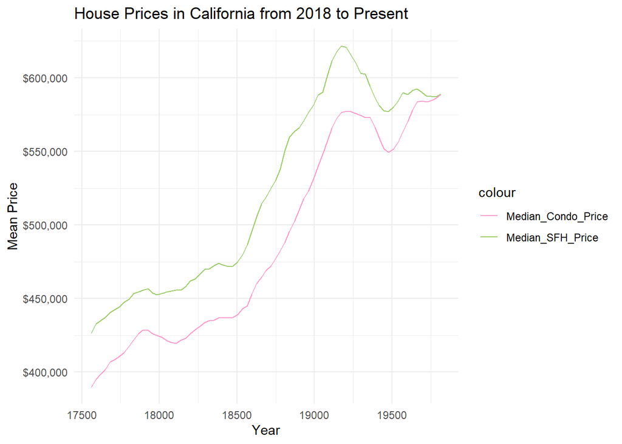

```r
# B1.1. Find Median Price
Median_HP_CA <- Join_HP_CA |>
                 group_by(Date) |>
                 summarize (Median_SFH_Price = median(SFH_Price, na.rm = TRUE),
                            Median_Condo_Price = median(Condo_Price, na.rm = TRUE))

Median_HP_CA$Date <- as.numeric(Median_HP_CA$Date) # convert Year Column to numeric

ggplot(Median_HP_CA, aes(x = Date)) +
  geom_line(aes(y = Median_SFH_Price, color = "Median_SFH_Price")) +
  geom_line(aes(y = Median_Condo_Price, color = "Median_Condo_Price")) +
  labs(title = "House Prices in California from 2018 to Present",
       x = "Year",
       y = "Mean Price") +
  scale_color_manual(values = c("Median_SFH_Price" = "#99CC66", "Median_Condo_Price" = "#FF99CC")) +
   scale_y_continuous(labels = scales::dollar_format(prefix = "$"), breaks = seq(0, 1000000, by = 50000)) +
   theme_minimal()
```

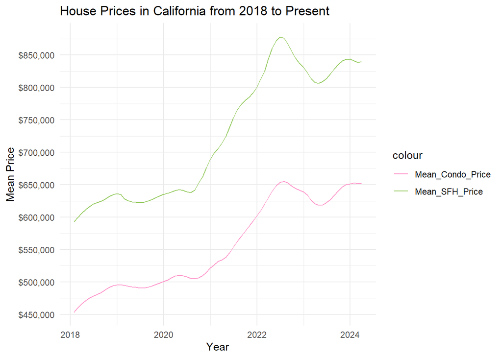

```r
# B1.2. Find Mean Price
Mean_HP_CA <- Join_HP_CA |>
                 group_by(Date) |>
                 summarize (Mean_SFH_Price = mean(SFH_Price, na.rm = TRUE),
                            Mean_Condo_Price = mean(Condo_Price, na.rm = TRUE)) |>
                 mutate(Year = year(Date))

Mean_HP_CA$Year <- as.numeric(Mean_HP_CA$Year) # convert Year Column to numeric

ggplot(Mean_HP_CA, aes(x = Date)) +
  geom_line(aes(y = Mean_SFH_Price, color = "Mean_SFH_Price")) +
  geom_line(aes(y = Mean_Condo_Price, color = "Mean_Condo_Price")) +
  labs(title = "House Prices in California from 2018 to Present",
       x = "Year",
       y = "Mean Price") +
  scale_color_manual(values = c("Mean_SFH_Price" = "#99CC66", "Mean_Condo_Price" = "#FF99CC")) +
  scale_y_continuous(labels = scales::dollar_format(prefix = "$"), breaks = seq(0, 1000000, by = 50000)) +
   theme_minimal()
```

Which county has experienced the highest increase in house pricing over the 2018-now period?

```r
# Find Median Price based on County and sort the data by median value from high to low
#Condo
Condo_CA_County <- Condo_CA |>
                    mutate(Year = format(Date, "%Y")) |>
                    group_by(Year, County) |>
                    summarize (Median_Condo_CA_County = median(Condo_Price, na.rm = TRUE),
                               .groups = 'drop') |>
                    arrange(desc(Year), desc(Median_Condo_CA_County))

Condo_CA_County
```

```
## # A tibble: 266 × 3
##    Year  County               Median_Condo_CA_County
##    <chr> <chr>                                 <dbl>
##  1 2024  Santa Clara County                 1088110.
##  2 2024  San Francisco County               1029751.
##  3 2024  Marin County                        991336.
##  4 2024  San Mateo County                    969827.
##  5 2024  Santa Barbara County                818375.
##  6 2024  Napa County                         785422.
##  7 2024  Alameda County                      776797.
##  8 2024  Santa Cruz County                   724278.
##  9 2024  Orange County                       706156.
## 10 2024  Mono County                         675812.
## # ℹ 256 more rows
```

```r
Highest_Condo_Prices_byYear <- Condo_CA_County |>
                     group_by(Year) |>
                     top_n(1, Median_Condo_CA_County)

Lowest_Condo_Prices_byYear <- Condo_CA_County |>
                     group_by(Year) |>
                     top_n(-1, Median_Condo_CA_County)

print(Highest_Condo_Prices_byYear)
```

```
## # A tibble: 7 × 3
## # Groups:   Year [7]
##   Year  County               Median_Condo_CA_County
##   <chr> <chr>                                 <dbl>
## 1 2024  Santa Clara County                 1088110.
## 2 2023  Santa Clara County                 1052618.
## 3 2022  San Francisco County               1190437.
## 4 2021  San Francisco County               1144428.
## 5 2020  San Francisco County               1159839.
## 6 2019  San Francisco County               1157583.
## 7 2018  San Francisco County               1159943.
```

```r
Lowest_Condo_Prices_byYear
```

```
## # A tibble: 7 × 3
## # Groups:   Year [7]
##   Year  County        Median_Condo_CA_County
##   <chr> <chr>                          <dbl>
## 1 2024  Sutter County                218984.
## 2 2023  Kern County                  219646.
## 3 2022  Kern County                  213224.
## 4 2021  Kern County                  174813.
## 5 2020  Kern County                  156418.
## 6 2019  Kern County                  137542.
## 7 2018  Kern County                  127368.
```

```r
#Single Family Home
SFH_CA_County <- SFH_CA |>
                    mutate(Year = format(Date, "%Y")) |>
                    group_by(Year, County) |>
                    summarize (Median_SFH_CA_County = median(SFH_Price, na.rm = TRUE),
                               .groups = 'drop') |>
                    arrange(desc(Year), desc(Median_SFH_CA_County))

SFH_CA_County
```

```
## # A tibble: 406 × 3
##    Year  County                 Median_SFH_CA_County
##    <chr> <chr>                                 <dbl>
##  1 2024  Santa Clara County                 2375502.
##  2 2024  San Mateo County                   1843651.
##  3 2024  Marin County                       1693946.
##  4 2024  Santa Barbara County               1460524.
##  5 2024  San Francisco County               1423316.
##  6 2024  Alameda County                     1304906.
##  7 2024  Orange County                      1257254.
##  8 2024  Santa Cruz County                  1079644.
##  9 2024  San Luis Obispo County              954789.
## 10 2024  Napa County                         945884.
## # ℹ 396 more rows
```

```r
Highest_SFH_Prices_byYear <- SFH_CA_County |>
                     group_by(Year) |>
                     top_n(1, Median_SFH_CA_County)

Lowest_SFH_Prices_byYear <- SFH_CA_County |>
                     group_by(Year) |>
                     top_n(-1, Median_SFH_CA_County)

print(Highest_SFH_Prices_byYear)
```

```
## # A tibble: 7 × 3
## # Groups:   Year [7]
##   Year  County             Median_SFH_CA_County
##   <chr> <chr>                             <dbl>
## 1 2024  Santa Clara County             2375502.
## 2 2023  Santa Clara County             2246121.
## 3 2022  Santa Clara County             2399325.
## 4 2021  Santa Clara County             2137917.
## 5 2020  Santa Clara County             1918001.
## 6 2019  Santa Clara County             1920263.
## 7 2018  Santa Clara County             1887510.
```

```r
Lowest_SFH_Prices_byYear
```

```
## # A tibble: 7 × 3
## # Groups:   Year [7]
##   Year  County       Median_SFH_CA_County
##   <chr> <chr>                       <dbl>
## 1 2024  Modoc County              205203.
## 2 2023  Modoc County              201926.
## 3 2022  Modoc County              193109.
## 4 2021  Modoc County              172599.
## 5 2020  Modoc County              150993.
## 6 2019  Modoc County              145087.
## 7 2018  Modoc County              139275.
```

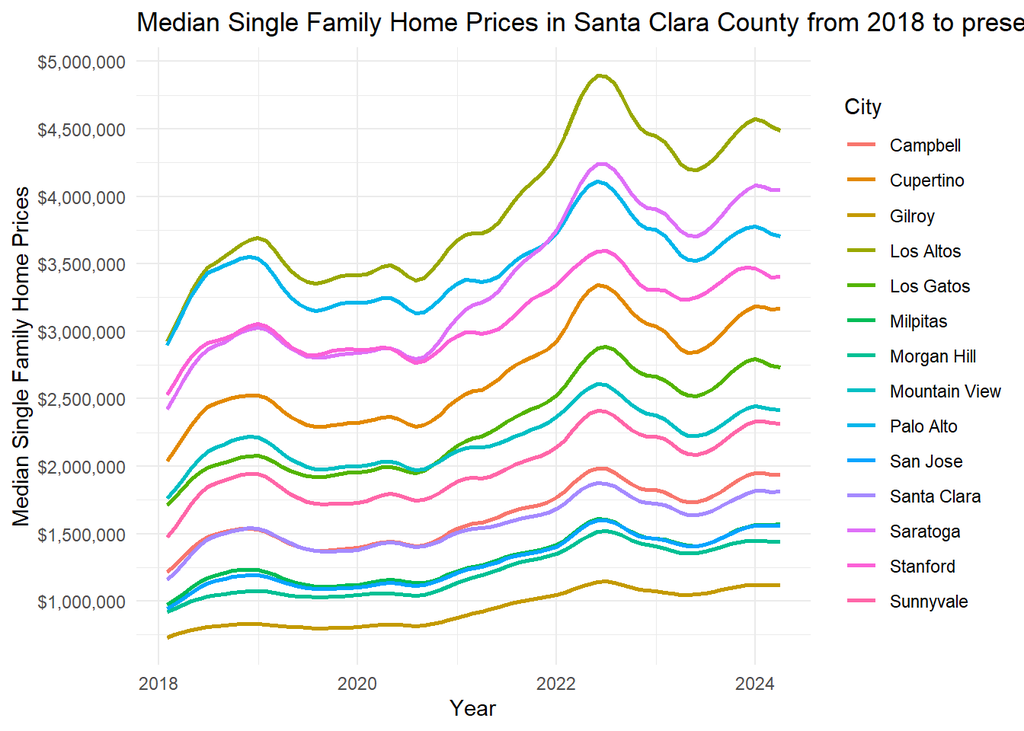

```r
# plot house prices in Santa Clara County
Median_HP_SantaClara <- Join_HP_CA |>
                 filter(County == "Santa Clara County")|>
                 group_by(Date, City) |>
                 summarize (Median_SFH_Price_SantaClara = median(SFH_Price, na.rm = TRUE),
                            Median_Condo_Price_SantaClara = median(Condo_Price, na.rm = TRUE))
Median_HP_SantaClara_filtered <- na.omit(Median_HP_SantaClara)

# plot Median Single Family Home Prices in Santa Clara COunty
ggplot(Median_HP_SantaClara_filtered,
       aes(x = Date, y = Median_SFH_Price_SantaClara, group = City, color = City)) +
       labs(title = "Median Single Family Home Prices in Santa Clara County from 2018 to present",
            x = "Year",
            y = "Median Single Family Home Prices")+
  geom_line(size = 1) +
  scale_y_continuous(labels = scales::dollar_format(prefix = "$"), breaks = seq(0, 5000000, by = 500000)) +
   theme_minimal()
```

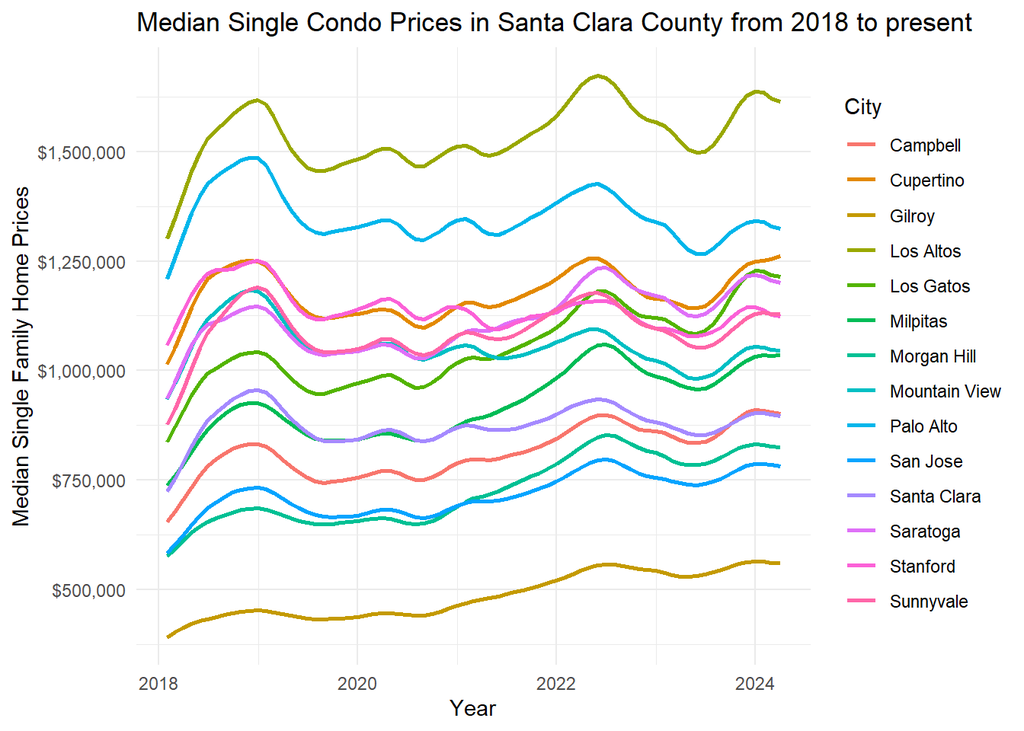

```r
# plot Median Condo Prices in Santa Clara County
ggplot(Median_HP_SantaClara_filtered,
       aes(x = Date, y = Median_Condo_Price_SantaClara, group = City, color = City)) +
       labs(title = "Median Single Condo Prices in Santa Clara County from 2018 to present",
            x = "Year",
            y = "Median Single Family Home Prices")+
  geom_line(size = 1) +
  scale_y_continuous(labels = scales::dollar_format(prefix = "$"), breaks = seq(0, 3000000, by = 250000)) +
  theme_minimal()
```

```r
#SFH
by_month_year_SFH <- SFH_CA |> mutate(Year = as.integer(format(as.Date(Date), "%Y")),Month = as.integer(format(as.Date(Date), "%m")))|>
    group_by(Year)
#mean price SFH by year
mean_by_year_SFH <- by_month_year_SFH |> group_by(Year, Month) |> summarize(mean_SFH_price = mean(SFH_Price,na.rm = TRUE),.groups = 'drop') |> ungroup()
```

```r
#Condo
by_month_year_Condo <- Condo_CA |> mutate(Year = as.integer(format(as.Date(Date), "%Y")),Month = as.integer(format(as.Date(Date), "%m")))|>
    group_by(Year)

#mean price Condo by year
mean_by_year_Condo <- by_month_year_Condo |> group_by(Year, Month) |> summarize(mean_Condo_price = mean(Condo_Price,na.rm = TRUE),.groups = 'drop') |> ungroup()
```

Rate30US Data

```r
by_month_year_rate30 <- rate30us |> mutate(Year = as.integer(format(as.Date(DATE), "%Y")),Month = as.integer(format(as.Date(DATE), "%m")))|>
    group_by(Year)

#MORGAGE RATE 30 US by YEAR/Month
by_month_year_rate30_from2018 <- filter(by_month_year_rate30, Year >="2018") |> group_by(Year, Month) |>summarize(mean_rate30 = mean(MORTGAGE30US,na.rm = TRUE),.groups = 'drop') |> ungroup()

#Merge/ combine date "by_month_year_rate30_from2018" and "mean_by_year_SFH"
SFH_with_rate30 <- full_join(by_month_year_rate30_from2018,mean_by_year_SFH, by = c("Month","Year" ))


#Merge/ combine date "by_month_year_rate30_from2018" and "mean_by_year_SFH"
Condo_with_rate30 <- full_join(by_month_year_rate30_from2018,mean_by_year_Condo, by = c("Month","Year" ))
```

Linear Regression

```r
#for SFH
lm_res_SHF = lm(mean_SFH_price ~ mean_rate30, data = SFH_with_rate30)
lm_res_SHF
```

```
##
## Call:
## lm(formula = mean_SFH_price ~ mean_rate30, data = SFH_with_rate30)
##
## Coefficients:
## (Intercept)  mean_rate30
##      549463        38750
```

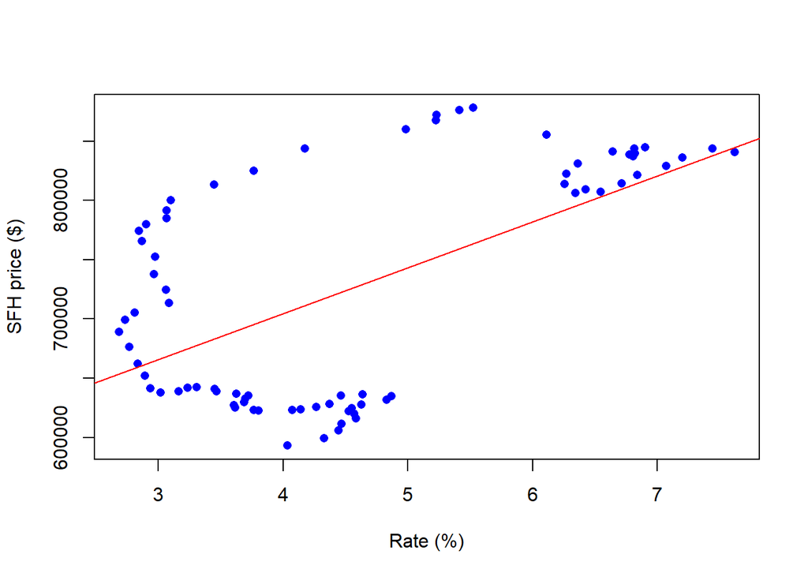

```r
#plot
plot(mean_SFH_price ~ mean_rate30, data = SFH_with_rate30,
     xlab = "Rate (%)",
     ylab = "SFH price ($)",
     pch  = 16, col  = "blue")
abline(lm_res_SHF,  col = "red")
```

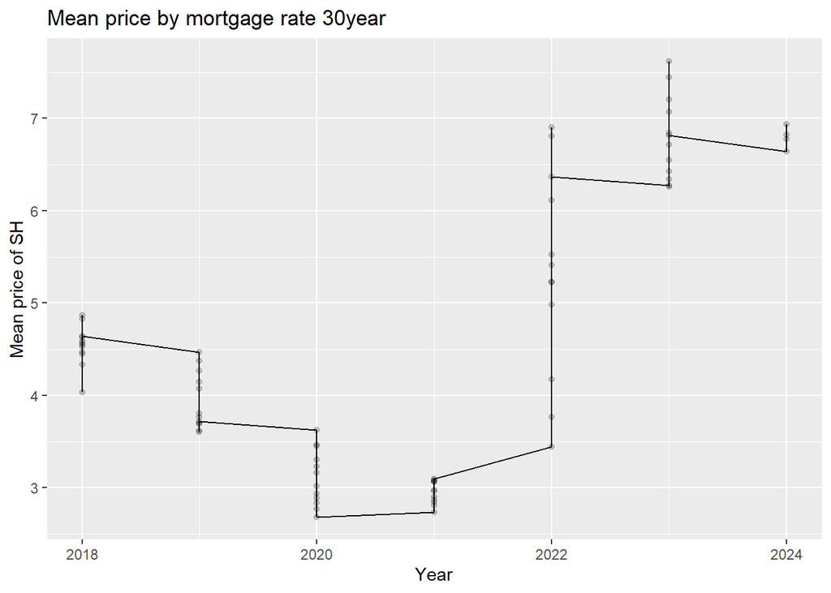

```r
library(ggplot2)
ggplot(data = SFH_with_rate30, aes(x = Year, y = mean_rate30)) +
  geom_line() + geom_point(alpha = 0.2) +
  xlab("Year") +ylab("Mean price of SH") + ggtitle("Mean price by mortgage rate 30year ")
```

```r
#For COndo
lm_res_Condo = lm(mean_Condo_price ~ mean_rate30, data = Condo_with_rate30)
lm_res_Condo
```

```
##
## Call:
## lm(formula = mean_Condo_price ~ mean_rate30, data = Condo_with_rate30)
##
## Coefficients:
## (Intercept)  mean_rate30
##      419034        30275
```

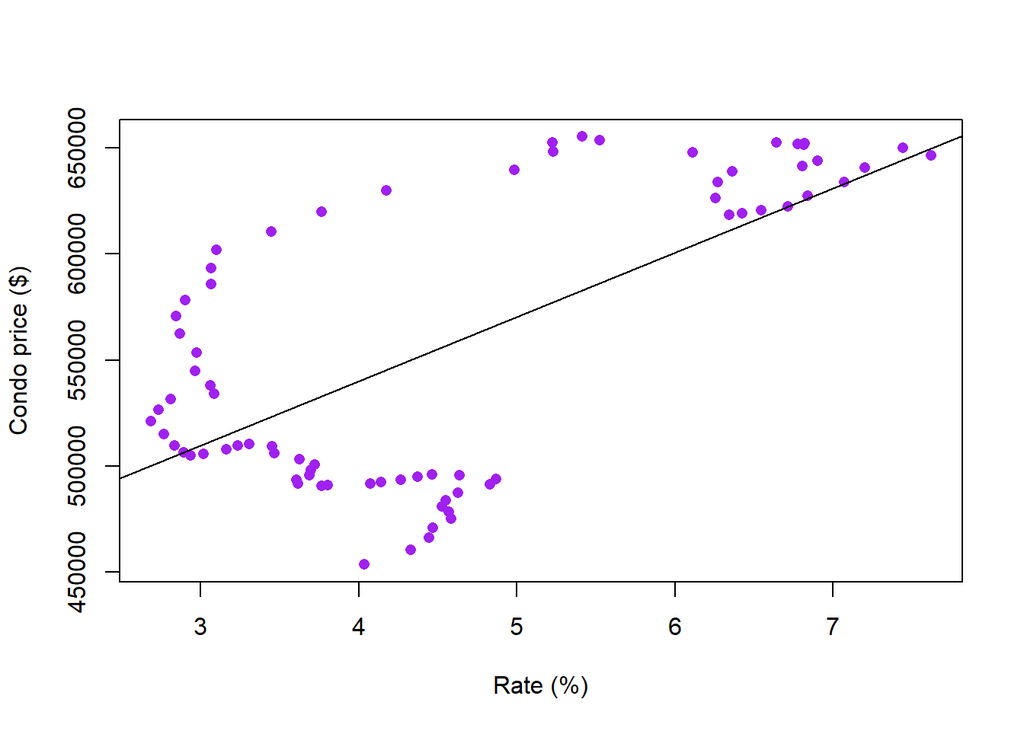

```r
#plot
plot(mean_Condo_price ~ mean_rate30, data = Condo_with_rate30,
     xlab = "Rate (%)",
     ylab = "Condo price ($)",
     pch  = 16, col  = "purple")
abline(lm_res_Condo,  col = "black")
```